# **Analyzing Common Chess Openings Across Various Elo Brackets**

By Seyed Mohammad Ghaemi

## **Introduction**

In this tutorial, we will be going through the data science pipeline

- Data Collection
- Data Management/Representation
- Exploratory Data Analysis
- Hypothesis Testing
- Communication of Insights

in order to gain an understanding of if and how certain factors, specifically ones such as Elo ranking, determine the opening moves of competitive chess players. The ultimate goal is to find out whether there is a significant difference between the common openings players of different elo's use.

Here is a list of assumptions made regarding what the reader already knows:

- An understanding of basic Python features
- An understanding of basic Pandas library features
- An understanding of basic Matplotlib library features
- An Understanding the fundamentals of chess and opening theory
- The ability to learn from documentation

## **Data Collection and Management**

In this section, we will first gather our chess data Lichess data set, then store features which we care about, and finally visualize a few examples along the way.

### Libraries

Here is a list of libraries we will be using and why we need them:

- We need os.path for basic path operations
- We need the urllib library to download from our chess database
- The chess database will give zipped files in bz2 format, so we will need the bz2 library to unzip them
- Each game in the database is stored as a PNG, the python-chess library will allow us to obtain the information stored in them
- Python's Pandas library is needed in order to store and manage our chess data.
- Scipy's stats library allows us to apply different hypothesis tests to our data

**Note**

To install python-chess simply run the command

```
pip install chess
```

Remember that there are other libraries that can handle PNGs as well, but for the purposes of this tutorial, we will use python-chess.

```python
import pandas as pd
import numpy as np
import matplotlib.pyplot as plt
import urllib.request
import bz2
import os.path
import chess.pgn as pgn
from scipy import stats
```

### Chess database background information

Lichess is a popular, opensource chess server that allows users to play online chess games as well as a variety of other chess-related activities. You can explore their site by clicking [here](http://www.lichess.org).

They have an open database of chess games that were played on their site, stored in monthly format, these can be found [here](https://database.lichess.org/).

The files are zipped using bz2 and games are formatted as PGN files. PGNs are one of the most popular standards when it comes to representing/storing chess games. You can learn more about them from [here](https://en.wikipedia.org/wiki/Portable_Game_Notation), however, we will be covering what information they store later in the tutorial.

### Getting the data

For the purposes of this tutorial, we will download the September 2014 data from the Lichess database site. I chose that particular dataset as it is only 159 MB which is quite low compared to the most recent ones which are 27 GB. We will still have just over a million games to analyze which is plenty. Once we have downloaded the data, we will unzip it using bz2.

```python
# Link to the dataset we want to download
url = 'https://database.lichess.org/standard/lichess_db_standard_rated_2014-09.pgn.bz2'
# Where we want to save the compressed file
save_location = './final/data/db.pgn.pz2'
# Where we want to save the decompressed file
save_loc_decomp = './final/data/db.pgn'

# Download and save dataset if the file does not exist already
if not os.path.isfile(save_location):
    urllib.request.urlretrieve(url, save_location)
    print("Successfully downloaded and stored file")
else:
    print("The file you want to download already exists!")

# Now we decompress the downloaded file and save it unless it already exists
if not os.path.isfile(save_loc_decomp):
    with open(save_loc_decomp, 'wb') as new_file, bz2.BZ2File(save_location, 'rb') as file:
        for data in iter(lambda : file.read(100 * 1024), b''):
            new_file.write(data)
    print("Finished decompressing file")
else:
    print("The file you want to decompress already exists!")

# Getting the PGN files
pgn_files = open(save_loc_decomp)
```

```
The file you want to download already exists!
The file you want to decompress already exists!
```

### Using the python-chess library

Now that we have our PGN data, we will use the python-chess library to obtain the information we are currently looking for, mainly the opening for each game, and the elo it happened in.

Once we obtain the PNG using the library, we can get the information we need by getting the header for each game. Headers consist of information about the chess game such as "BlackElo", "WhiteElo", "ECO", "Opening", "Date", and more. The **pgn.read_game()** command can be used to get the information behind an entire game. The problem with this is that we do not necessarily want how the entire game played out given to us, especially since we will be reading more than a million matches! This is where the **pgn.read_headers()** method becomes useful as it allows us to retrieve the header information from the current game.

More information on the various methods in the library can be found in the documentation [here](https://python-chess.readthedocs.io/en/latest/pgn.html).

**Note**

Note that the PGNs are stored in a stack format and each time we call one of the read commands, the PGN or game at the top of the stack is taken out and given to us.

Below we will use some of the tools we just learned about.

```python
# Getting the PGN files, note that calling this resets which game we are at
pgn_files = open(save_loc_decomp)
# Getting the first game in our file
game = pgn.read_game(pgn_files)
# Displaying the end of the first game
game.end().board()
```

[figure not shown]

```python
# Getting the next game in our file
game = pgn.read_game(pgn_files)
# We can get a specific header, in this case the opening, like so
print("The opening was", game.headers["Opening"])
# Printing all the information about this game
print(game)
```

```
The opening was Polish Opening: Czech Defense
[Event "Rated Blitz game"]
[Site "https://lichess.org/PK5H93NR"]
[Date "????.??.??"]
[Round "?"]
[White "mustroll"]
[Black "pelao"]
[Result "1-0"]
[BlackElo "1658"]
[BlackRatingDiff "-13"]
[ECO "A00"]
[Opening "Polish Opening: Czech Defense"]
[Termination "Normal"]
[TimeControl "240+2"]
[UTCDate "2014.08.31"]
[UTCTime "22:00:53"]
[WhiteElo "1600"]
[WhiteRatingDiff "+13"]

1. b4 e5 2. Bb2 d6 3. c3 Bf5 4. d3 Nf6 5. e4 Bg6 6. Be2 Be7 7. Nf3 O-O 8. O-O Nc6 9. Nbd2 d5 10. b5 dxe4 11. bxc6 exf3 12. Bxf3 bxc6 13. Bxc6 Rb8 14. Nc4 e4 15. dxe4 Qxd1 16. Rfxd1 Nxe4 17. Bxe4 Bxe4 18. f3 Bf5 19. Ba3 Bxa3 20. Nxa3 Rb2 21. c4 Be6 22. Rdc1 Rd8 23. Rc2 Rxc2 24. Nxc2 Bxc4 25. Na3 Ba6 …
```

```python
# Getting the next game except this time we only get the headers
header = pgn.read_headers(pgn_files)
# We can get a specific header, in this case the opening, like so
print("The opening was", header["Opening"])
# Printing all the header information about this game
print(header)
```

```
The opening was Russian Game: Three Knights Game
Headers(Event='Rated Blitz game', Site='https://lichess.org/4CnlXUB0', White='martinz', Black='HighP', Result='1-0', BlackElo='1650', BlackRatingDiff='-13', ECO='C42', Opening='Russian Game: Three Knights Game', Termination='Normal', TimeControl='300+0', UTCDate='2014.08.31', UTCTime='22:00:17', Whi…
```

### Storing the chess data into Pandas

From the list of header information, we'll deem the WhiteElo, BlackElo, ECO, and Opening as the information that will help us determine common openings for different elo ranges. So our first task will be to go through the data and store those into a dictionary.

```python
# Initializing our dictionary of information
info = {"WhiteElo": [],
        "BlackElo": [],
        "ECO": [],
        "Opening": []}

# Reset our position in the pgn files
pgn_files = open(save_loc_decomp)
# While we have more games left, add the game information we care about
# into the dictionary
headers = pgn.read_headers(pgn_files)
while headers is not None:
    for k in info:
        info[k].append(headers[k])
    # Get next game's header
    headers = pgn.read_headers(pgn_files)
```

Now that we have a dictionary where each key is essentially a column of data, we can convert this into a pandas table.

```python
# Convert dict to a pandas table
info_tbl = pd.DataFrame.from_dict(info)
# Display a sample of it
info_tbl
```

|  | WhiteElo | BlackElo | ECO | Opening |
| --- | --- | --- | --- | --- |
| 0 | 1833 | 1823 | A06 | Zukertort Opening: Tennison Gambit |
| 1 | 1600 | 1658 | A00 | Polish Opening: Czech Defense |
| 2 | 1754 | 1790 | B01 | Scandinavian Defense: Main Line |
| 3 | 1601 | 1650 | C42 | Russian Game: Three Knights Game |
| 4 | 1657 | 1545 | D31 | Semi-Slav Defense: Accelerated Move Order |
| ... | ... | ... | ... | ... |
| 1000051 | 1492 | 1498 | C30 | King's Gambit Declined, Petrov's Defense |
| 1000052 | 1642 | 1862 | D02 | Queen's Pawn Game: Zukertort Variation |
| 1000053 | 1713 | 1490 | C50 | Italian Game: Giuoco Pianissimo |
| 1000054 | 2169 | 1880 | D06 | Queen's Gambit Refused: Marshall Defense |
| 1000055 | 1919 | 1742 | C02 | French Defense: Advance Variation, Nimzowitsch... |

1000056 rows × 4 columns

### Formatting the Pandas data

Note that there are multiple flaws with our current table that will make it harder to process later on. These are:

- Some values in each category are missing and as such are marked with "?", so we must figure out how to handle those cases.
- The elo data is of type string when it should be an integer
- We will want to group the elo data into intervals
- When grouping into intervals, we may want to create binary columns where a 0 means the row is not in an interval, and a 1 means the data is in an interval
- We may want to combine the White and Black elo into one group through techniques like averaging to make analysis easier

First let's handle the missing data since we will not be able to turn "?" into integers in the case of elo without doing this step. Let's look at different scenarios where the data is missing for each category as a way to help us figure out which technique will serve us best.

```python
print("A preview for a table with all rows missing WhiteElo")
print(info_tbl["WhiteElo"][info_tbl["WhiteElo"]=="?"].count(), "missing")
info_tbl[info_tbl["WhiteElo"]=="?"]
```

```
A preview for a table with all rows missing WhiteElo
20 missing
```

|  | WhiteElo | BlackElo | ECO | Opening |
| --- | --- | --- | --- | --- |
| 133566 | ? | 1768 | ? | ? |
| 154626 | ? | 2322 | ? | ? |
| 154900 | ? | 1500 | ? | ? |
| 243899 | ? | 1683 | ? | ? |
| 244404 | ? | 1742 | ? | ? |
| 272116 | ? | 1112 | ? | ? |
| 305867 | ? | 1903 | ? | ? |
| 305905 | ? | 1903 | ? | ? |
| 305976 | ? | 1903 | ? | ? |
| 438061 | ? | 2541 | ? | ? |
| 505128 | ? | 1455 | ? | ? |
| 505131 | ? | 1455 | ? | ? |
| 533590 | ? | 2549 | ? | ? |
| 637411 | ? | 1554 | ? | ? |
| 637437 | ? | 1554 | ? | ? |
| 637455 | ? | 1554 | ? | ? |
| 934077 | ? | 1371 | ? | ? |
| 973932 | ? | 1521 | ? | ? |
| 974004 | ? | 1521 | ? | ? |
| 974100 | ? | 1521 | ? | ? |

```python
print("A preview for a table with all rows missing BlackElo")
print(info_tbl["BlackElo"][info_tbl["BlackElo"]=="?"].count(), "missing")
info_tbl[info_tbl["BlackElo"]=="?"]
```

```
A preview for a table with all rows missing BlackElo
20 missing
```

|  | WhiteElo | BlackElo | ECO | Opening |
| --- | --- | --- | --- | --- |
| 133573 | 1563 | ? | ? | ? |
| 154491 | 1579 | ? | ? | ? |
| 243880 | 1309 | ? | ? | ? |
| 272110 | 1549 | ? | ? | ? |
| 272250 | 1337 | ? | ? | ? |
| 505012 | 1710 | ? | ? | ? |
| 505017 | 1710 | ? | ? | ? |
| 570463 | 1539 | ? | ? | ? |
| 637091 | 1621 | ? | ? | ? |
| 637178 | 1393 | ? | ? | ? |
| 637182 | 1393 | ? | ? | ? |
| 637313 | 1554 | ? | ? | ? |
| 637338 | 1527 | ? | ? | ? |
| 637350 | 1895 | ? | ? | ? |
| 637450 | 1249 | ? | ? | ? |
| 906168 | 1916 | ? | ? | ? |
| 933552 | 1500 | ? | ? | ? |
| 934191 | 1371 | ? | ? | ? |
| 973954 | 1521 | ? | ? | ? |
| 973986 | 1521 | ? | ? | ? |

```python
print("A preview for a table with all rows missing ECO")
print(info_tbl["ECO"][info_tbl["ECO"]=="?"].count(), "missing")
info_tbl[info_tbl["ECO"]=="?"]
```

```
A preview for a table with all rows missing ECO
96 missing
```

|  | WhiteElo | BlackElo | ECO | Opening |
| --- | --- | --- | --- | --- |
| 6954 | 1758 | 1922 | ? | ? |
| 7030 | 1541 | 1280 | ? | ? |
| 133566 | ? | 1768 | ? | ? |
| 133573 | 1563 | ? | ? | ? |
| 133578 | 1369 | 1500 | ? | ? |
| ... | ... | ... | ... | ... |
| 973986 | 1521 | ? | ? | ? |
| 973996 | 1366 | 1703 | ? | ? |
| 974004 | ? | 1521 | ? | ? |
| 974008 | 1629 | 1703 | ? | ? |
| 974100 | ? | 1521 | ? | ? |

96 rows × 4 columns

```python
print("A preview for a table with all rows missing Opening")
print(info_tbl["Opening"][info_tbl["Opening"]=="?"].count(), "missing")
info_tbl[info_tbl["Opening"]=="?"]
```

```
A preview for a table with all rows missing Opening
96 missing
```

|  | WhiteElo | BlackElo | ECO | Opening |
| --- | --- | --- | --- | --- |
| 6954 | 1758 | 1922 | ? | ? |
| 7030 | 1541 | 1280 | ? | ? |
| 133566 | ? | 1768 | ? | ? |
| 133573 | 1563 | ? | ? | ? |
| 133578 | 1369 | 1500 | ? | ? |
| ... | ... | ... | ... | ... |
| 973986 | 1521 | ? | ? | ? |
| 973996 | 1366 | 1703 | ? | ? |
| 974004 | ? | 1521 | ? | ? |
| 974008 | 1629 | 1703 | ? | ? |
| 974100 | ? | 1521 | ? | ? |

96 rows × 4 columns

Looking at the tables, it's clear that whenever one of the elo features is missing, the ECO and Opening is also missing. Furthermore, there is only a total of 40 rows where one of the elo features is missing and out of over a million rows, this should not be a big problem.

As for the ECO and Opening columns, since they are representations of the same thing, if one of them is missing then they are both missing. There are a total of 96 rows where the ECO and Opening information is missing with 40 of those being the same as the 40 from the elo missing data.

The 40 which contain missing elo's can be thrown out as they are MCAR and not missing because of some observed/unobserved data. On the other hand, the 56 rows with missing ECO/Opening data must be kept as they may be a part of the group where the players simply did not play an established opening, so we will want the "?" as its own Opening category.

```python
# Removing rows with missing elo
info_tbl = info_tbl[info_tbl["WhiteElo"] != "?"]
info_tbl = info_tbl[info_tbl["BlackElo"] != "?"]
```

Now we will convert the elo columns into integers

```python
info_tbl["WhiteElo"] = info_tbl["WhiteElo"].astype(int)
info_tbl["BlackElo"] = info_tbl["BlackElo"].astype(int)
```

Now we want to tidy the elo columns so that they are based on columns of intervals that are marked as 0 or 1 depending on which interval they belong in.

```python
# First let's look at the min and max
print("White has max", info_tbl["WhiteElo"].max(), "and min",info_tbl["WhiteElo"].min())
print("Black has max", info_tbl["BlackElo"].max(), "and min",info_tbl["BlackElo"].min())
```

```
White has max 2708 and min 751
Black has max 2711 and min 737
```

For the sake of consistency across both groups, let's say we have a min of 720 and max of 2720. We can split this into 5 groups of range 400 each for a total of 10 groups since white and black are separate.

```python
bins = pd.IntervalIndex.from_tuples([(720,1120), (1120,1520), (1520,1920), (1920,2320), (2320,2720)])
info_tbl["Int_WhiteElo"] = pd.cut(info_tbl.WhiteElo, bins)
info_tbl["Int_BlackElo"] = pd.cut(info_tbl.BlackElo, bins)
# See a sample of our new data
info_tbl.head()
```

|  | WhiteElo | BlackElo | ECO | Opening | Int_WhiteElo | Int_BlackElo |
| --- | --- | --- | --- | --- | --- | --- |
| 0 | 1833 | 1823 | A06 | Zukertort Opening: Tennison Gambit | (1520, 1920] | (1520, 1920] |
| 1 | 1600 | 1658 | A00 | Polish Opening: Czech Defense | (1520, 1920] | (1520, 1920] |
| 2 | 1754 | 1790 | B01 | Scandinavian Defense: Main Line | (1520, 1920] | (1520, 1920] |
| 3 | 1601 | 1650 | C42 | Russian Game: Three Knights Game | (1520, 1920] | (1520, 1920] |
| 4 | 1657 | 1545 | D31 | Semi-Slav Defense: Accelerated Move Order | (1520, 1920] | (1520, 1920] |

Now we create dummy columns which are set to 0 or 1 depending on if they are a part of an interval.

```python
# Getting the dummy columns
white_dummies = pd.get_dummies(info_tbl.Int_WhiteElo, drop_first=True, prefix="WhiteElo")
black_dummies = pd.get_dummies(info_tbl.Int_BlackElo, drop_first=True, prefix="BlackElo")
# Concatenating new columns into a new table
info_tbl_int = pd.concat([info_tbl, white_dummies, black_dummies], axis=1)
# Display a sample of the table
info_tbl_int.head()
```

|  | WhiteElo | BlackElo | ECO | Opening | Int_WhiteElo | Int_BlackElo | WhiteElo_(1120, 1520] | WhiteElo_(1520, 1920] | WhiteElo_(1920, 2320] | WhiteElo_(2320, 2720] | BlackElo_(1120, 1520] | BlackElo_(1520, 1920] | BlackElo_(1920, 2320] | BlackElo_(2320, 2720] |
| --- | --- | --- | --- | --- | --- | --- | --- | --- | --- | --- | --- | --- | --- | --- |
| 0 | 1833 | 1823 | A06 | Zukertort Opening: Tennison Gambit | (1520, 1920] | (1520, 1920] | 0 | 1 | 0 | 0 | 0 | 1 | 0 | 0 |
| 1 | 1600 | 1658 | A00 | Polish Opening: Czech Defense | (1520, 1920] | (1520, 1920] | 0 | 1 | 0 | 0 | 0 | 1 | 0 | 0 |
| 2 | 1754 | 1790 | B01 | Scandinavian Defense: Main Line | (1520, 1920] | (1520, 1920] | 0 | 1 | 0 | 0 | 0 | 1 | 0 | 0 |
| 3 | 1601 | 1650 | C42 | Russian Game: Three Knights Game | (1520, 1920] | (1520, 1920] | 0 | 1 | 0 | 0 | 0 | 1 | 0 | 0 |
| 4 | 1657 | 1545 | D31 | Semi-Slav Defense: Accelerated Move Order | (1520, 1920] | (1520, 1920] | 0 | 1 | 0 | 0 | 0 | 1 | 0 | 0 |

We'll do the same but on a column that consists of the average between the white and black elo of the game.

```python
# New column with average of White and Black elo
info_tbl_int["Avg_Elo"] = info_tbl_int.loc[:, "WhiteElo":"BlackElo"].mean(axis=1)
# Turn average elo column into intervals of same sizes as before
bins = pd.IntervalIndex.from_tuples([(720,1120), (1120,1520), (1520,1920), (1920,2320), (2320,2720)])
info_tbl_int["Int_AvgElo"] = pd.cut(info_tbl_int.Avg_Elo, bins)
# See a sample of our new data
info_tbl_int.head()
```

|  | WhiteElo | BlackElo | ECO | Opening | Int_WhiteElo | Int_BlackElo | WhiteElo_(1120, 1520] | WhiteElo_(1520, 1920] | WhiteElo_(1920, 2320] | WhiteElo_(2320, 2720] | BlackElo_(1120, 1520] | BlackElo_(1520, 1920] | BlackElo_(1920, 2320] | BlackElo_(2320, 2720] | Avg_Elo | Int_AvgElo |
| --- | --- | --- | --- | --- | --- | --- | --- | --- | --- | --- | --- | --- | --- | --- | --- | --- |
| 0 | 1833 | 1823 | A06 | Zukertort Opening: Tennison Gambit | (1520, 1920] | (1520, 1920] | 0 | 1 | 0 | 0 | 0 | 1 | 0 | 0 | 1828.0 | (1520, 1920] |
| 1 | 1600 | 1658 | A00 | Polish Opening: Czech Defense | (1520, 1920] | (1520, 1920] | 0 | 1 | 0 | 0 | 0 | 1 | 0 | 0 | 1629.0 | (1520, 1920] |
| 2 | 1754 | 1790 | B01 | Scandinavian Defense: Main Line | (1520, 1920] | (1520, 1920] | 0 | 1 | 0 | 0 | 0 | 1 | 0 | 0 | 1772.0 | (1520, 1920] |
| 3 | 1601 | 1650 | C42 | Russian Game: Three Knights Game | (1520, 1920] | (1520, 1920] | 0 | 1 | 0 | 0 | 0 | 1 | 0 | 0 | 1625.5 | (1520, 1920] |
| 4 | 1657 | 1545 | D31 | Semi-Slav Defense: Accelerated Move Order | (1520, 1920] | (1520, 1920] | 0 | 1 | 0 | 0 | 0 | 1 | 0 | 0 | 1601.0 | (1520, 1920] |

Now that we have cleaned up our data, we can move on to visualizing and exploring it in preparation for our final analysis.

## **Exploratory Data Analysis**

First we will plot the frequency of each of the top 10 openings for each interval.

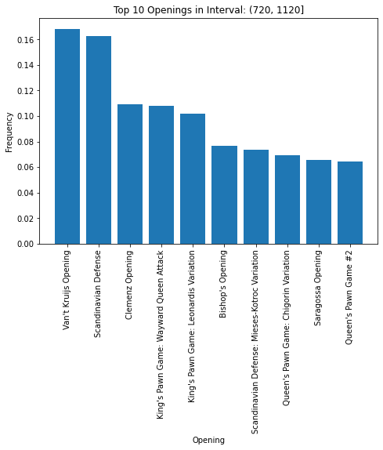

```python
# Group the table by their average interval
for k, tbl in info_tbl_int.groupby("Int_AvgElo"):
    # Print top 10 most used Openings
    X = tbl["Opening"].value_counts()[0:10].keys()
    Y = tbl["Opening"].value_counts()[0:10].values
    # We want to normalize the frequency across graphs
    Y = Y / Y.sum()
    fig = plt.figure()
    ax = fig.add_axes([0,0,1,1])
    ax.bar(X, Y)
    ax.set_title("Top 10 Openings in Interval: " + str(k))
    ax.set_xlabel("Opening")
    ax.set_ylabel("Frequency")
    # Setting rotation to 90 so that the texts don't get mixed up
    plt.xticks(rotation=90)
    ax.plot()
    # Only printing the first one for reference
    break
```

Unfortunately, the opening names are too long so instead we will use the ECO opening classification system as our x-tick labels

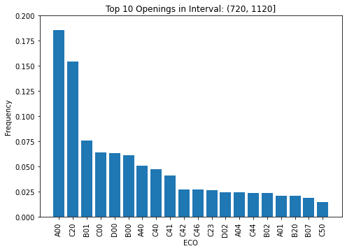

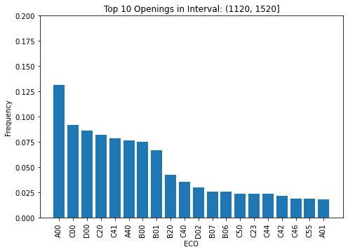

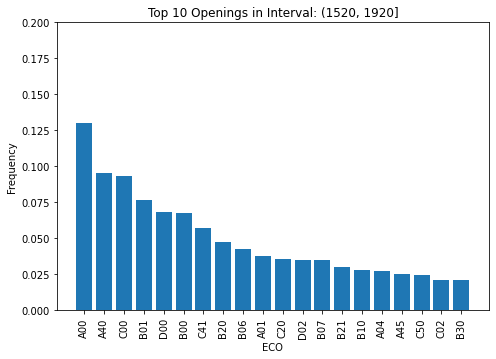

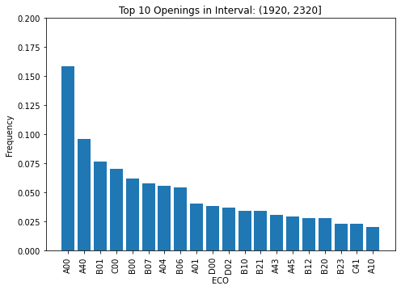

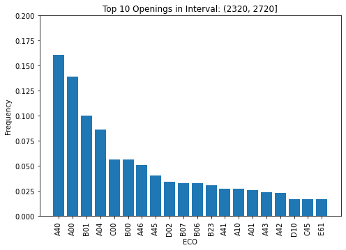

```python
# Group the table by their average interval
for k, tbl in info_tbl_int.groupby("Int_AvgElo"):
    # Print top 20 most used Openings
    X = tbl["ECO"].value_counts()[0:20].keys()
    Y = tbl["ECO"].value_counts()[0:20].values
    # We want to normalize the frequency across graphs
    Y = Y / Y.sum()
    fig = plt.figure()
    ax = fig.add_axes([0,0,1,1])
    ax.bar(X, Y)
    ax.set_title("Top 10 Openings in Interval: " + str(k))
    ax.set_xlabel("ECO")
    ax.set_ylabel("Frequency")
    # Setting rotation to 90 so that the texts don't get mixed up
    plt.xticks(rotation=90)
    # Making y-axis the same across all graphs so we can compare the intervals
    plt.ylim(0, 0.2)
    ax.plot()
```

The visuals above suggest that an expected, general decrease in opening frequency as we get further away from more popular openings until it reaches a certain point where the frequency does not decrease as much. Throughout the first four intervals, the opening A00 is most commonly used but in the final interval, A40 is the most popular one. The graphs seem to show that the top openings are indeed changing across our elo intervals. For example here are the top 5 for each of our 5 intervals:

1. A00, C20, B01, C00, D00
2. A00, C00, D00, C20, C41
3. A00, A40, C00, B01, D00
4. A00, A40, B01, C00, B00
5. A40, A00, B01, A04, C00

However, it is important to note that while plots do show downward trend in popularity, the difference in frequency is not as high as one might think looking at the graphs. For example, in interval 4, the difference between the first and second opening (A00, A40) is only around 5%.

Continuing from that, maybe we also want to see if there are certain openings that are unique to specific elo intervals. For this, we will use the Term Frequency-Inverse Document Frequency (TF-IDF) algorithm. This is a technique that, for every term in a document, determines whether that term is unique to this document (occurs multiple times in the document and not many times in other documents). In our case, the documents are our 5 intervals and the terms are the opening codes. You can learn more about this statistical tool [here](https://monkeylearn.com/blog/what-is-tf-idf/).

```python
# All unique ECO openings
all_eco = set(info_tbl_int["ECO"].values)
# One counter dictionary for each interval
dicts = [{key: 0 for key in all_eco} for i in range(5)]

i = 0
# Go through each interval and add to the counter of the appropriate dict's opening
for k, tbl in info_tbl_int.groupby("Int_AvgElo"):
    for val in tbl["ECO"].values:
        dicts[i][val] += 1
    i += 1

# Calculates the term frequency
def tf(freqs, doc_i, opening):
    # Term frequency of opening appearing in the doc_i interval
    tf = freqs[doc_i][opening] / sum(freqs[doc_i].values())
    # We take the log to reduce outliers
    return np.log(1 + tf)

# Calculates the inverse document frequency
def idf(freqs, opening):
    num_doc = len(freqs)
    # Number of intervals/docs opening appears in
    appears = 0
    for doc in freqs:
        appears += 1 if doc[opening] != 0 else 0
    return np.log(num_doc / appears)

# Calculates the tf-idf
def tf_idf(freqs, doc_i, opening):
    return tf(freqs, doc_i, opening) * idf(freqs, opening)

# Testing our tfidf, this should give us 0 since A00 appears in all intervals
tfidf = tf_idf(dicts, 0, "A00")
print("TF-IDF of opening A00 in doc 0 is", tfidf)
```

```
TF-IDF of opening A00 in doc 0 is 0.0
```

Now we will compute the tf-idf of each term (opening) in each of our documents (intervals)

```python
# We will store the result in a 2d array where each row is the interval we are at
# and each column is the tfidf for each opening
tfidf_lst = [[],[],[],[],[]]
uniques = set(all_eco)
for i in range(5):
    for val in uniques:
        tfidf = tf_idf(dicts, i, val)
        tfidf_lst[i].append((val, tfidf))
    tfidf_lst[i].sort(key=lambda x: -x[1])

# Let's display a small sample
tfidf_lst[0][:10]
```

```
[('C40', 0.007799986190833881),
 ('C24', 0.0018299557315451715),
 ('D20', 0.0016111517741731372),
 ('C65', 0.0006605142010162426),
 ('C62', 0.0005872202107647992),
 ('C34', 0.0005139021383739046),
 ('C61', 0.00033050149411027513),
 ('A27', 0.0002570990094634617),
 ('A29', 0.0002570990094634617),
 ('B29', 0.0001836723713168222)]
```

For each interval, we will plot the top 10 potentially unique openings based on the tf-idf. Again, we will make sure the y-axis are the same so that we could compare the unique openings across intervals too.

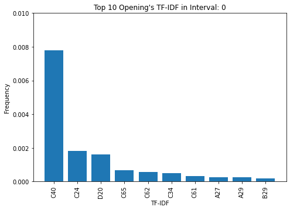

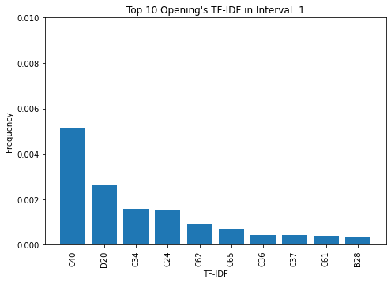

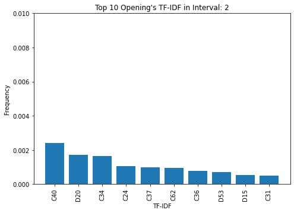

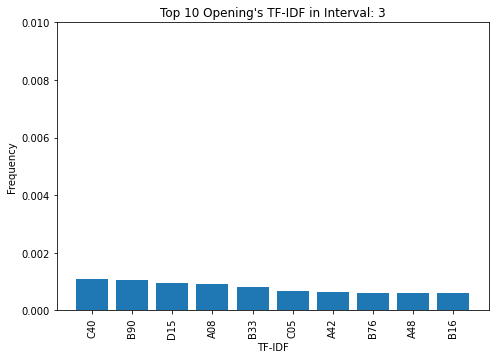

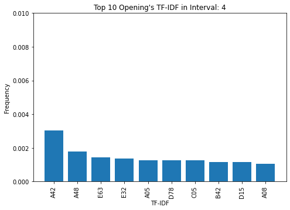

```python
# Going through each interval
for i in range(5):
    # ECO
    X = [name for name, tfidf in tfidf_lst[i][:10]]
    # TF-IDF of ECO
    Y = [tfidf for name, tfidf in tfidf_lst[i][:10]]
    fig = plt.figure()
    ax = fig.add_axes([0,0,1,1])
    ax.bar(X, Y)
    ax.set_title("Top 10 Opening's TF-IDF in Interval: " + str(i))
    ax.set_xlabel("TF-IDF")
    ax.set_ylabel("Frequency")
    # Setting rotation to 90 so that the texts don't get mixed up
    plt.xticks(rotation=90)
    # Making y-axis the same across all graphs so we can compare the intervals
    plt.ylim(0, 0.01)
    ax.plot()
```

The plots suggest that while some openings may be unique to the lower elo intervals, there is a general trend that as we go to the higher elo intervals, the tf-idf decreases. One major factor that is probably causing this is the fact that the distribution of the number of games is not even across intervals, and that there is a concentration of them in the central intervals. Another factor may be that more experienced players have a broader range of openings which they choose from, so their games may have more variety.

## **Hypothesis Testing**

Say we want to know if there is a significant statistical difference between how the openings are distributed in the beginner elo levels versus the higher elo levels. For this job, we will be using the Mann-Whitney U Test which is a hypothesis test that is used to detect differences between two datasets. Learn more about this test [here](https://www.statology.org/mann-whitney-u-test/).

Our null hypothesis is that there is no significant difference between the first and last interval's opening distribution. We will be using the default alpha level of 0.05 since we are only analyzing chess elo levels and people's lives are not dependent on this so a higher confidence is not needed.

First we will get a histogram for each of the intervals, then we will utilize scipy.stats' mannwhitneyu method to calculate our p-value.

```python
# Get the u-statistic and p-value
u_statistic, p_value = stats.mannwhitneyu(list(dicts[0].values()), list(dicts[4].values()))

print("The U-statistic is", u_statistic, "\nThe p-value is", '{0:f}'.format(p_value))
```

[output not shown]

Since the p-value of 0.000056 is less than our alpha (0.05), we can reject the null hypothesis which means that there is a statistically significant difference between the distribution of openings of the first and last interval.

Unfortunately, our tf-idf distributions are dependent to each other since we incorprate the other documents when calculating the tf-idf for a term in a document. Since the Mann-Whitney U Test assumes the distributions are independent, we cannot perform the hypothesis test on our tf-idf distributions.

## **Communication**

### Conclusion

Using the Elo and Opening data from Lichess's September 2014 dataset, we found that the data suggested a difference between the distribution of higher and lower elo intervals. This could be a result of higher ranked players utilizing different or perhaps simply a wider range of openings when compared to a lower ranked player.

### Future analysis

One factor that we could fix int the future is to compensate for the lack of balance in distributions by getting more data and randomly sampling an equal amount of games for each elo interval. Speaking of intervals, we could also test smaller sized-intervals which may lead to finding more patterns.

Lastly, we could attempt to use the tf-idf opening data of players as well as machine learning to attempt to classify what elo interval certain players belong in.

### What we learned

Throughout this guide we learned about accessing and downloading data from databases and loading them through Python. We learned about working with PGN and how the popular python-chess library worked. We processed and tidied data given to us by Lichess using common data science techniques such as the use of dummy columns. We handled missing data cases and applied other data management operations on our data with Pandas. We also learned to visualize the chess data with matplotlib. Analysis techniques like tf-idf allowed us to gain a better understanding of our data, and finally, we used hypothesis testing to make statistically significant observations about our data.

I hope you were able to gain an understanding of the data science pipeline using this tutorial. If you found any issues, please report them so that they can be fixed!